# ExtraaLearn Project

## Context

The EdTech industry has been surging in the past decade immensely, and according to a forecast, the Online Education market would be worth $286.62bn by 2023 with a compound annual growth rate (CAGR) of 10.26% from 2018 to 2023. The modern era of online education has enforced a lot in its growth and expansion beyond any limit. Due to having many dominant features like ease of information sharing, personalized learning experience, transparency of assessment, etc, it is now preferable to traditional education.

In the present scenario due to the Covid-19, the online education sector has witnessed rapid growth and is attracting a lot of new customers. Due to this rapid growth, many new companies have emerged in this industry. With the availability and ease of use of digital marketing resources, companies can reach out to a wider audience with their offerings. The customers who show interest in these offerings are termed as leads. There are various sources of obtaining leads for Edtech companies, like

- The customer interacts with the marketing front on social media or other online platforms.
- The customer browses the website/app and downloads the brochure
- The customer connects through emails for more information.

The company then nurtures these leads and tries to convert them to paid customers. For this, the representative from the organization connects with the lead on call or through email to share further details.

## Objective

ExtraaLearn is an initial stage startup that offers programs on cutting-edge technologies to students and professionals to help them upskill/reskill. With a large number of leads being generated on a regular basis, one of the issues faced by ExtraaLearn is to identify which of the leads are more likely to convert so that they can allocate resources accordingly. You, as a data scientist at ExtraaLearn, have been provided the leads data to:

- Analyze and build an ML model to help identify which leads are more likely to convert to paid customers,
- Find the factors driving the lead conversion process
- Create a profile of the leads which are likely to convert

## Data Description

The data contains the different attributes of leads and their interaction details with ExtraaLearn. The detailed data dictionary is given below.

**Data Dictionary**

- ID: ID of the lead
- age: Age of the lead
- current_occupation: Current occupation of the lead. Values include 'Professional','Unemployed',and 'Student'
- first_interaction: How did the lead first interacted with ExtraaLearn. Values include 'Website', 'Mobile App'
- profile_completed: What percentage of profile has been filled by the lead on the website/mobile app. Values include Low - (0-50%), Medium - (50-75%), High (75-100%)
- website_visits: How many times has a lead visited the website
- time_spent_on_website: Total time spent on the website
- page_views_per_visit: Average number of pages on the website viewed during the visits.
- last_activity: Last interaction between the lead and ExtraaLearn.
  - Email Activity: Seeking for details about program through email, Representative shared information with lead like brochure of program , etc
  - Phone Activity: Had a Phone Conversation with representative, Had conversation over SMS with representative, etc
  - Website Activity: Interacted on live chat with representative, Updated profile on website, etc
- print_media_type1: Flag indicating whether the lead had seen the ad of ExtraaLearn in the Newspaper.
- print_media_type2: Flag indicating whether the lead had seen the ad of ExtraaLearn in the Magazine.
- digital_media: Flag indicating whether the lead had seen the ad of ExtraaLearn on the digital platforms.
- educational_channels: Flag indicating whether the lead had heard about ExtraaLearn in the education channels like online forums, discussion threads, educational websites, etc.
- referral: Flag indicating whether the lead had heard about ExtraaLearn through reference.
- status: Flag indicating whether the lead was converted to a paid customer or not.

## Importing necessary libraries and data

```python
import warnings

warnings.filterwarnings("ignore")
from statsmodels.tools.sm_exceptions import ConvergenceWarning

warnings.simplefilter("ignore", ConvergenceWarning)

# Libraries to help with reading and manipulating data

import pandas as pd
import numpy as np

# Library to split data
from sklearn.model_selection import train_test_split

# libaries to help with data visualization
import matplotlib.pyplot as plt
import seaborn as sns

# Removes the limit for the number of displayed columns
pd.set_option("display.max_columns", None)
# Sets the limit for the number of displayed rows
pd.set_option("display.max_rows", 200)
# setting the precision of floating numbers to 5 decimal points
pd.set_option("display.float_format", lambda x: "%.5f" % x)

# To build model for prediction
import statsmodels.stats.api as sms
from statsmodels.stats.outliers_influence import variance_inflation_factor
import statsmodels.api as sm
from statsmodels.tools.tools import add_constant
from sklearn.linear_model import LogisticRegression
from sklearn.tree import DecisionTreeClassifier
from sklearn import tree
from sklearn.ensemble import RandomForestClassifier

# To tune different models
from sklearn.model_selection import GridSearchCV


# To get diferent metric scores
import sklearn.metrics as metrics
from sklearn.metrics import (
    f1_score,
    accuracy_score,
    recall_score,
    precision_score,
    confusion_matrix,
    classification_report,
    roc_auc_score,
    precision_recall_curve,
    roc_curve,
    make_scorer,
)
```

## Data Overview

- Observations
- Sanity checks

```python
df = pd.read_csv("ExtraaLearn.csv")
```

```python
df.head()
```

|  | ID | age | current_occupation | first_interaction | profile_completed | website_visits | time_spent_on_website | page_views_per_visit | last_activity | print_media_type1 | print_media_type2 | digital_media | educational_channels | referral | status |
| --- | --- | --- | --- | --- | --- | --- | --- | --- | --- | --- | --- | --- | --- | --- | --- |
| 0 | EXT001 | 57 | Unemployed | Website | High | 7 | 1639 | 1.86100 | Website Activity | Yes | No | Yes | No | No | 1 |
| 1 | EXT002 | 56 | Professional | Mobile App | Medium | 2 | 83 | 0.32000 | Website Activity | No | No | No | Yes | No | 0 |
| 2 | EXT003 | 52 | Professional | Website | Medium | 3 | 330 | 0.07400 | Website Activity | No | No | Yes | No | No | 0 |
| 3 | EXT004 | 53 | Unemployed | Website | High | 4 | 464 | 2.05700 | Website Activity | No | No | No | No | No | 1 |
| 4 | EXT005 | 23 | Student | Website | High | 4 | 600 | 16.91400 | Email Activity | No | No | No | No | No | 0 |

##### **Observations:**

From the first few rows of the dataset, we can observe that each row represents a unique lead identified by the ID column.

The dataset contains a mix of:

1-Numerical variables such as:

age, website_visits, time_spent_on_website, page_views_per_visit

2-Categorical variables such as:

current_occupation, first_interaction, profile_completed, last_activity

3-Binary categorical variables (Yes/No flags) such as:

print_media_type1, print_media_type2, digital_media, educational_channels,referral

The target variable is status, where:

1 indicates that the lead converted to a paid customer.

0 indicates that the lead did not convert.

```python
df.dtypes
```

|  | 0 |
| --- | --- |
| ID | object |
| age | int64 |
| current_occupation | object |
| first_interaction | object |
| profile_completed | object |
| website_visits | int64 |
| time_spent_on_website | int64 |
| page_views_per_visit | float64 |
| last_activity | object |
| print_media_type1 | object |
| print_media_type2 | object |
| digital_media | object |
| educational_channels | object |
| referral | object |
| status | int64 |

**dtype:** object

##### **Observations:**

age, website_visits, time_spent_on_website, and status are stored as int64, meaning they are integer numerical variables.

page_views_per_visit is stored as float64, indicating it contains decimal values and represents a continuous numerical variable.

Most categorical variables such as current_occupation, first_interaction, profile_completed, and last_activity are stored as object, meaning they will require encoding before being used in machine learning models.

The media exposure and referral variables (print_media_type1, print_media_type2, digital_media, educational_channels, referral) are also stored as object, even though they represent binary (Yes/No) information. These will need to be converted into numerical format for modeling.

```python
df.shape
```

```
(4612, 15)
```

##### **Observation:**

The dataset contains 4,612 observations and 15 variables.

```python
df.describe()
```

|  | age | website_visits | time_spent_on_website | page_views_per_visit | status |
| --- | --- | --- | --- | --- | --- |
| count | 4612.00000 | 4612.00000 | 4612.00000 | 4612.00000 | 4612.00000 |
| mean | 46.20121 | 3.56678 | 724.01127 | 3.02613 | 0.29857 |
| std | 13.16145 | 2.82913 | 743.82868 | 1.96812 | 0.45768 |
| min | 18.00000 | 0.00000 | 0.00000 | 0.00000 | 0.00000 |
| 25% | 36.00000 | 2.00000 | 148.75000 | 2.07775 | 0.00000 |
| 50% | 51.00000 | 3.00000 | 376.00000 | 2.79200 | 0.00000 |
| 75% | 57.00000 | 5.00000 | 1336.75000 | 3.75625 | 1.00000 |
| max | 63.00000 | 30.00000 | 2537.00000 | 18.43400 | 1.00000 |

##### **Observations:**

**1-Age**

Age ranges from 18 to 63 years.

The average age is 46 years, while the median is 51 years.

This suggests a slight left skew (median > mean), indicating a larger concentration of older leads.

**2-Website Visits**

The average number of visits is 3.57, with a maximum of 30 visits.

Since the 75th percentile is 5 visits, 30 visits may indicate potential outliers.

**3-Time Spent on Website**

The average time spent is 724 seconds.

The median is 376 seconds, which is much lower than the mean.

The large difference between mean and median suggests the presence of right-skewness and potential outliers.

Maximum time spent is 2537 seconds, which may represent highly engaged leads.

**4-Page Views per Visit**

The average is 3.02 pages per visit.

The maximum value is 18.43, which appears unusually high and may indicate outliers or extreme engagement behavior.

**5-Status**

The mean of status is 0.2986, meaning approximately 29.9% of leads converted.

This indicates that the dataset is moderately imbalanced, with fewer conversions than non-conversions.

```python
# --- Sanity Checks ---
print("\n--- Missing Values Check ---")
print(df.isnull().sum())

print("\n--- Duplicate Records Check ---")
print(f"Total duplicate rows: {df.duplicated().sum()}")

print("\n--- Duplicate ID Check ---")
print(f"Total duplicate rows: {df['ID'].duplicated().sum()}")
```

```
--- Missing Values Check ---
ID                       0
age                      0
current_occupation       0
first_interaction        0
profile_completed        0
website_visits           0
time_spent_on_website    0
page_views_per_visit     0
last_activity            0
print_media_type1        0
print_media_type2        0
digital_media            0
educational_channels     0
referral                 0
status                   0
dtype: int64

--- Duplicate Records Check ---
Total duplicate rows: 0

--- Duplicate ID Check ---
Total duplicate rows: 0
```

##### **Observations:**

Missing Values: There are no missing values in the dataset. This is ideal, as it means we do not need to apply imputation techniques (like filling with mean/median) which can sometimes introduce bias.

Duplicate Records: There are 0 total duplicate rows, meaning no two entries are identical across all features.

Duplicate ID Check: The count of duplicate IDs is 0. Since we have 4,612 total rows and 4,612 unique IDs, we can confirm that ID is a unique identifier for each lead.

Data Integrity: The absence of missing values and duplicates suggests a high level of data quality, allowing us to proceed to Exploratory Data Analysis (EDA) without heavy cleaning.

## Exploratory Data Analysis (EDA)

- EDA is an important part of any project involving data.
- It is important to investigate and understand the data better before building a model with it.
- A few questions have been mentioned below which will help you approach the analysis in the right manner and generate insights from the data.
- A thorough analysis of the data, in addition to the questions mentioned below, should be done.

**Questions**

1. Leads will have different expectations from the outcome of the course and the current occupation may play a key role in getting them to participate in the program. Find out how current occupation affects lead status.
2. The company's first impression on the customer must have an impact. Do the first channels of interaction have an impact on the lead status?
3. The company uses multiple modes to interact with prospects. Which way of interaction works best?
4. The company gets leads from various channels such as print media, digital media, referrals, etc. Which of these channels have the highest lead conversion rate?
5. People browsing the website or mobile application are generally required to create a profile by sharing their personal data before they can access additional information.Does having more details about a prospect increase the chances of conversion?

### Univariate Analysis - Numerical Variables

```
Feature: age
Skew : -0.72
```

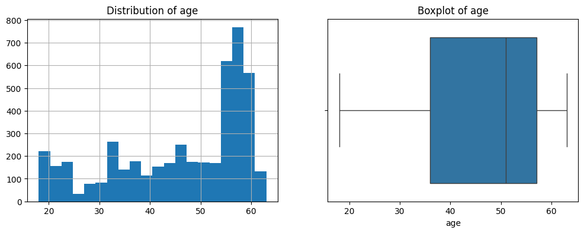

```
Feature: website_visits
Skew : 2.16
```

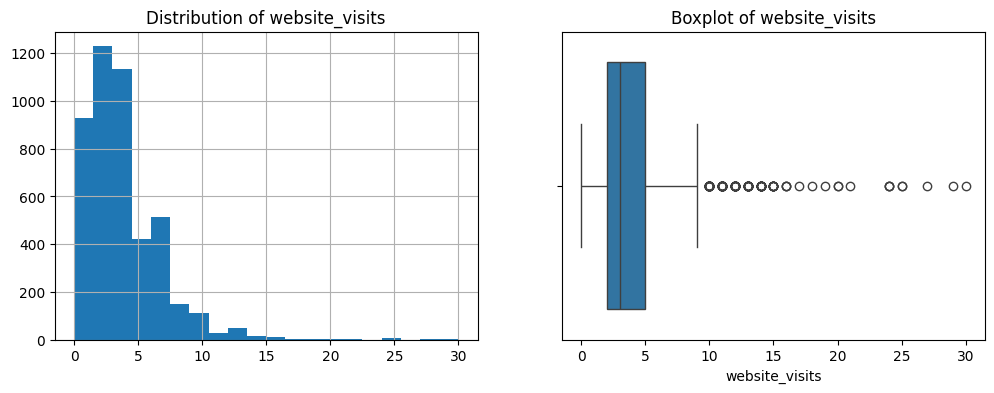

```
Feature: time_spent_on_website
Skew : 0.95
```

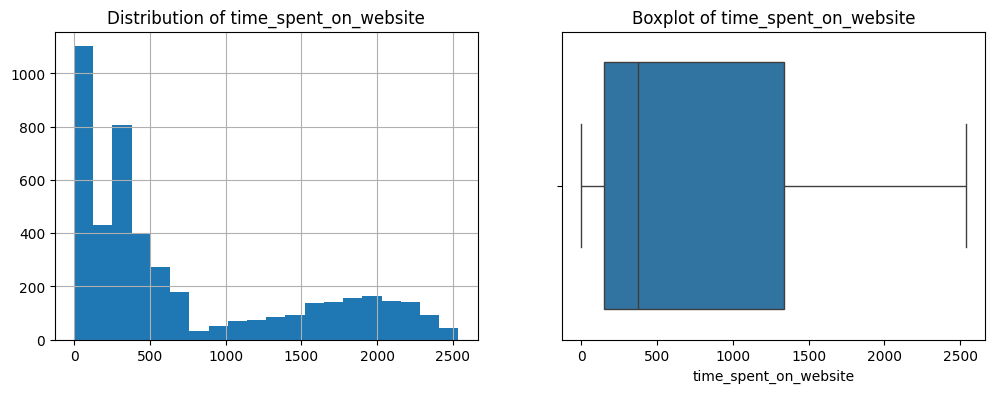

```
Feature: page_views_per_visit
Skew : 1.27
```

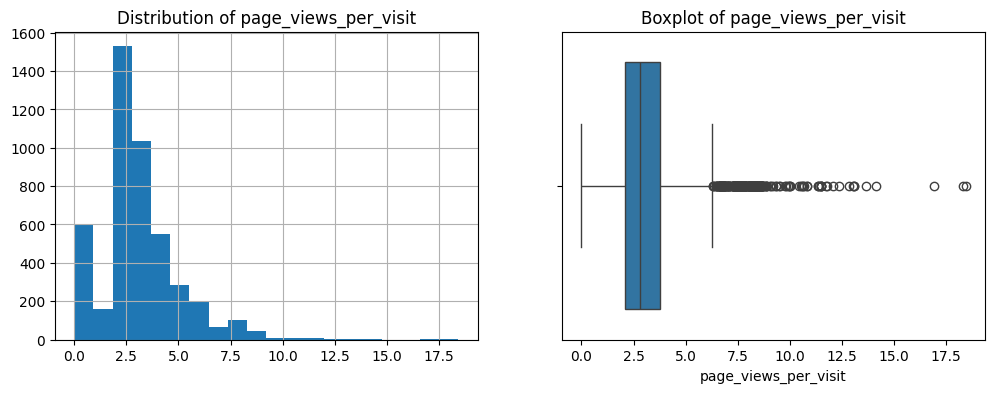

```python
cont_cols = df.select_dtypes(include=['int64','float64']).columns

for col in cont_cols:
    if col != 'status':
        print(f"Feature: {col}")
        print('Skew :', round(df[col].skew(),2))

        plt.figure(figsize=(12,4))

        plt.subplot(1,2,1)
        df[col].hist(bins=20)
        plt.title(f"Distribution of {col}")

        plt.subplot(1,2,2)
        sns.boxplot(x=df[col])
        plt.title(f"Boxplot of {col}")

        plt.show()
```

##### **Observations:**

**Age**

Slightly left-skewed (-0.72).

Indicates a concentration of leads in the higher age range.

**Website Visits**

Highly right-skewed (2.16).

Most leads visit the website only a few times, but some visit many times (long tail).

**Time Spent on Website**

Right skewed (0.95).

Majority spend moderate time, with some users spending significantly more time.

**Page Views per Visit**

Right skewed (1.27).

Some outliers exist but they are not extremely distant.

**Outliers**

Mild outliers are present in website_visits and page_views_per_visit. These variables show right-skewed distributions, with a few higher-value observations.

Since these extreme values may represent highly engaged users rather than data errors, a final decision regarding treatment will be taken during the Data Preprocessing stage.

### Univariate Analysis - Categorical Variables

```python
cat_cols = [
    'current_occupation', 'first_interaction', 'profile_completed',
    'last_activity', 'print_media_type1', 'print_media_type2',
    'digital_media', 'educational_channels', 'referral', 'status'
]
for i in cat_cols:
    print(df[i].value_counts(normalize=True))
    print('*'*40)
```

```
current_occupation
Professional   0.56722
Unemployed     0.31245
Student        0.12034
Name: proportion, dtype: float64
first_interaction
Website      0.55117
Mobile App   0.44883
Name: proportion, dtype: float64
profile_completed
High     0.49089
Medium   0.48591
Low      0.02320
Name: proportion, dtype: float64
last_activity
Email Activity     0.49393
Phone Activity     0.26756
Website Activity   0.23851
Name: proportion, dtype: float64
print_media_type1
No    0.89224
Yes   0.10776
Name: proportion, dtype: float64
print_media_type2
No    0.94948
Yes   0.05052
Name: proportion, dtype: float64
digital_media
No    0.88573
Yes   0.11427
Name: proportion, dtype: float64
educational_channels
No    0.84714
Yes   0.15286
Name: proportion, dtype: float64
referral
No    0.97984
Yes   0.02016
Name: proportion, dtype: float64
status
0   0.70143
1   0.29857
Name: proportion, dtype: float64
```

##### **observations:**

**Target Variable (status)**

Around 29.86% of the leads were converted, while 70.14% were not converted.

This indicates a class imbalance, with non-converted leads being the majority.

Model evaluation metrics such as Recall, Precision, and F1-score will be important instead of relying only on accuracy.

**Current Occupation**

Majority of leads are Professionals (56.7%).

Unemployed leads represent 31.2%.

Students account for only 12%.

The dataset is dominated by working professionals, which may influence conversion patterns.

**First Interaction**

55.1% of leads interacted first through the Website.

44.9% came through the Mobile App.

Both channels generate a significant share of leads.

**Profile Completed**

Almost half of the leads have High (49.1%) or Medium (48.6%) profile completion.

Only 2.3% of leads have Low completion.

This suggests most users are engaged enough to fill out a considerable portion of their profile.

**Last Activity**

Most recent interactions are:

Email Activity (49.4%)

Phone Activity (26.8%)

Website Activity (23.9%)

Email appears to be the most common follow-up interaction method.

**Marketing Channels (Print, Digital, Educational, Referral)**

Majority of leads did not come from:

Print Media Type 1 (89%)

Print Media Type 2 (95%)

Digital Media (88%)

Educational Channels (85%)

Only 2% of leads came through referrals, indicating referrals are rare in volume.

### Bivariate and Multivariate analysis - Categorical Variables

```
--- Conversion Table for current_occupation (Percentage) ---
status                    0        1
current_occupation
Professional       64.49000 35.51000
Student            88.29000 11.71000
Unemployed         73.42000 26.58000
```

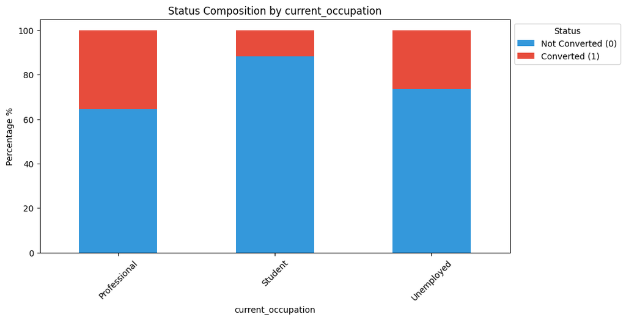

```
------------------------------------------------------------

--- Conversion Table for first_interaction (Percentage) ---
status                   0        1
first_interaction
Mobile App        89.47000 10.53000
Website           54.41000 45.59000
```

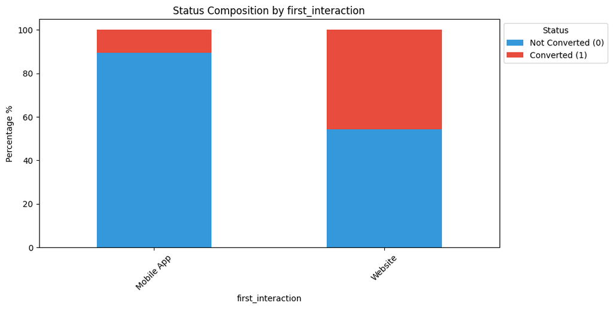

```
------------------------------------------------------------

--- Conversion Table for profile_completed (Percentage) ---
```

```
status                   0        1
profile_completed
High              58.22000 41.78000
Low               92.52000  7.48000
Medium            81.12000 18.88000
```

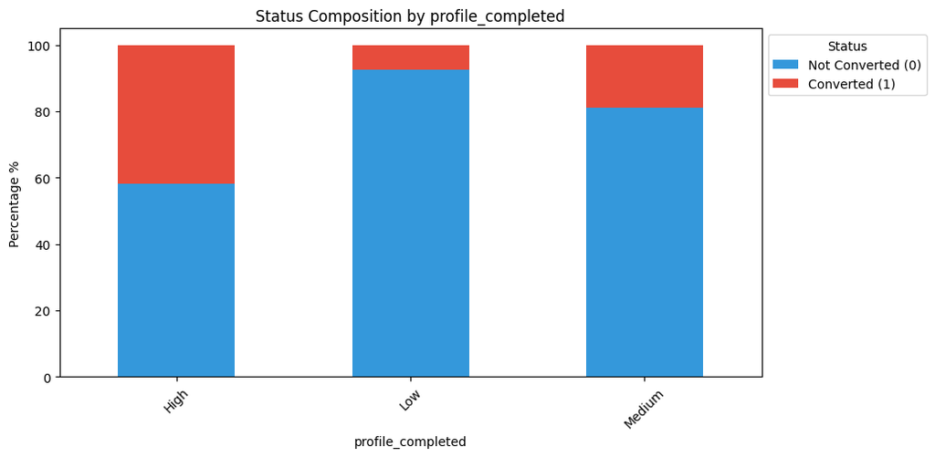

```
------------------------------------------------------------

--- Conversion Table for last_activity (Percentage) ---
status                  0        1
last_activity
Email Activity   69.67000 30.33000
Phone Activity   78.69000 21.31000
Website Activity 61.55000 38.45000
```

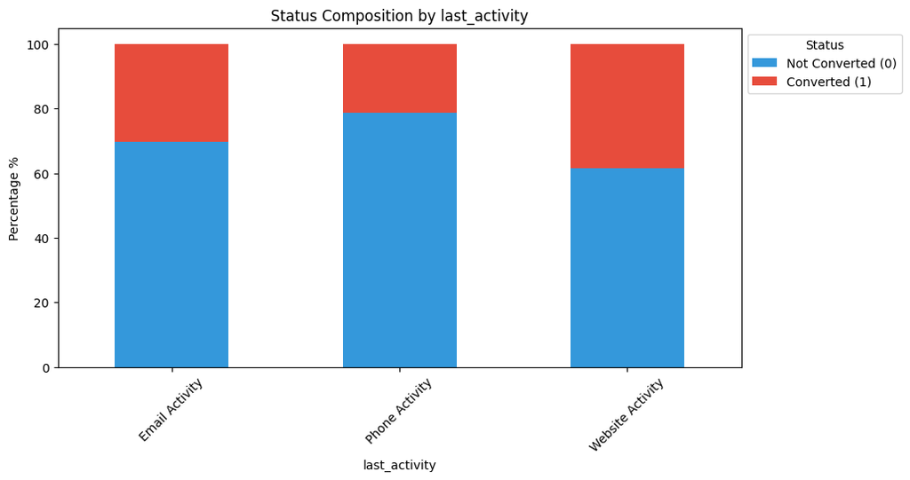

```
------------------------------------------------------------

--- Conversion Table for print_media_type1 (Percentage) ---
```

```
status                   0        1
print_media_type1
No                70.40000 29.60000
Yes               68.01000 31.99000
```

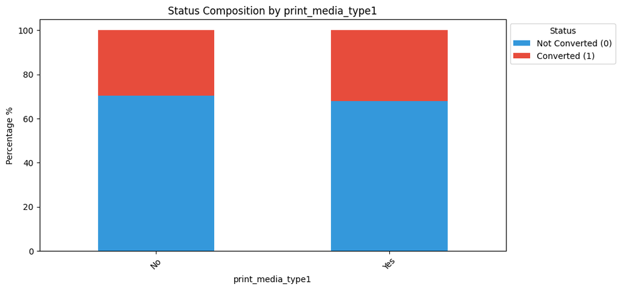

```
------------------------------------------------------------

--- Conversion Table for print_media_type2 (Percentage) ---
status                   0        1
print_media_type2
No                70.27000 29.73000
Yes               67.81000 32.19000
```

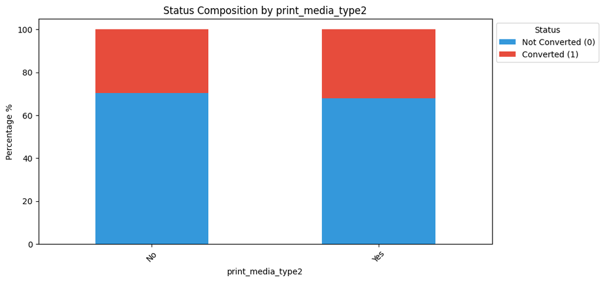

```
------------------------------------------------------------

--- Conversion Table for digital_media (Percentage) ---
status               0        1
digital_media
No            70.40000 29.60000
Yes           68.12000 31.88000
```

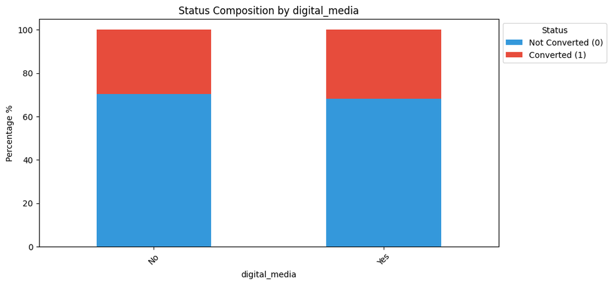

```
------------------------------------------------------------

--- Conversion Table for educational_channels (Percentage) ---
status                      0        1
educational_channels
No                   69.80000 30.20000
Yes                  72.06000 27.94000
```

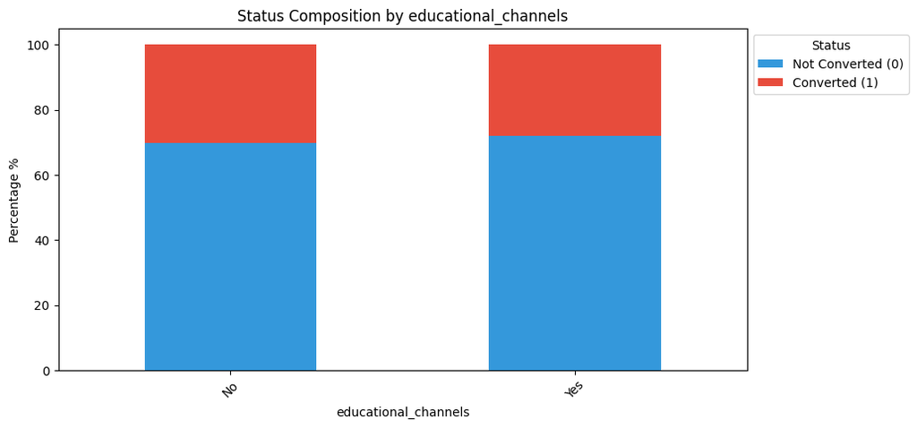

```
------------------------------------------------------------

--- Conversion Table for referral (Percentage) ---
status          0        1
referral
No       70.92000 29.08000
Yes      32.26000 67.74000
```

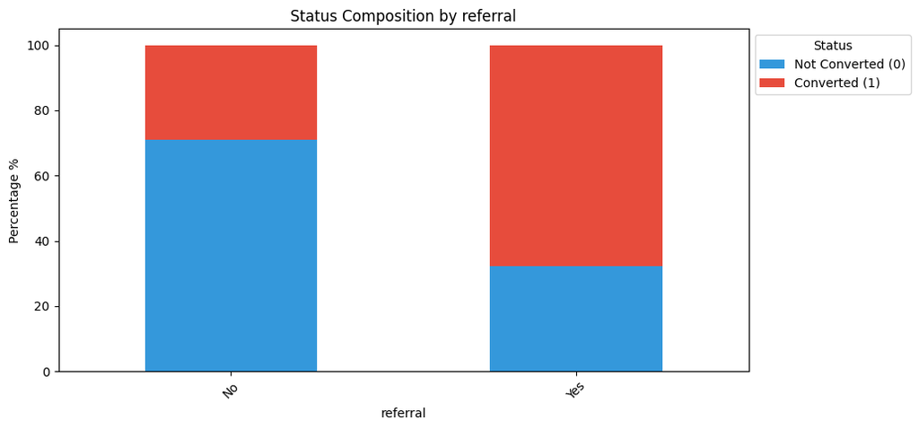

```python
for i in cat_cols:
    if i != 'status':
        # 1. O NÚMERO: Tabela de Contingência (em %)
        print(f"\n--- Conversion Table for {i} (Percentage) ---")
        conversion_table = pd.crosstab(df[i], df['status'], normalize='index') * 100
        print(conversion_table.round(2))

        # 2. O GRÁFICO: Stacked Bar Chart (Azul e Vermelho)
        # Usando as cores que definimos: Azul para 0 e Vermelho para 1
        conversion_table.plot(kind='bar', figsize=(10, 5), stacked=True, color=['#3498db', '#e74c3c'])

        plt.title(f'Status Composition by {i}')
        plt.ylabel('Percentage %')
        plt.xlabel(i)

        # Ajustando a legenda para fora do gráfico para não cobrir as barras
        plt.legend(title='Status', labels=['Not Converted (0)', 'Converted (1)'],
                   loc='upper left', bbox_to_anchor=(1, 1))

        plt.xticks(rotation=45)
        plt.show()
        print("-" * 60)
```

##### **Observations:**

**Current Occupation vs Status**

Professionals have the highest conversion rate (35.5%).

Unemployed leads convert at 26.6%.

Students have the lowest conversion rate (11.7%).

Occupation clearly influences conversion. Working professionals are more likely to enroll, possibly due to financial stability and career growth motivation.

**First Interaction vs Status**

Website leads convert at 45.6%.

Mobile App leads convert at only 10.5%.

First interaction channel has a strong impact. Website users are significantly more likely to convert than Mobile App users.

**Profile Completed vs Status**

High profile completion -> 41.8% conversion

Medium -> 18.9%

Low -> 7.5%

Strong positive relationship between profile completion and conversion. The more information a lead provides, the higher the probability of conversion.

This suggests engagement level is a key predictor.

**Last Activity vs Status**

Website Activity -> 38.5% conversion

Email Activity -> 30.3%

Phone Activity -> 21.3%

Website interactions and email follow-ups perform better than phone calls. Phone activity shows the lowest conversion rate.

**Marketing Channels vs Status** Print & Digital Media

Very small differences in conversion rates (~30–32%).

These channels do not show strong impact individually.

Educational Channels

Slightly lower conversion rate (27.9%) compared to non-educational leads.

**Referral**

Extremely high conversion rate: 67.7%

Non-referral leads convert at only 29.1%.

Referrals are the most powerful acquisition channel, even though they represent only 2% of leads.

### Bivariate and Multivariate analysis - Numerical Variables

```
--- Mean of age by Status ---
status
0   45.15301
1   48.66376
Name: age, dtype: float64
```

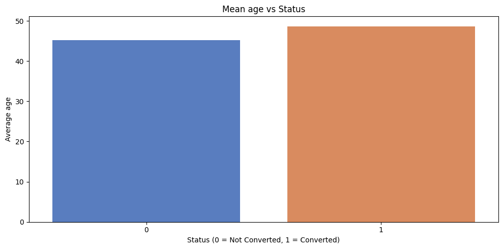

```
--------------------------------------------------

--- Mean of website_visits by Status ---
status
0   3.57898
1   3.53813
Name: website_visits, dtype: float64
```

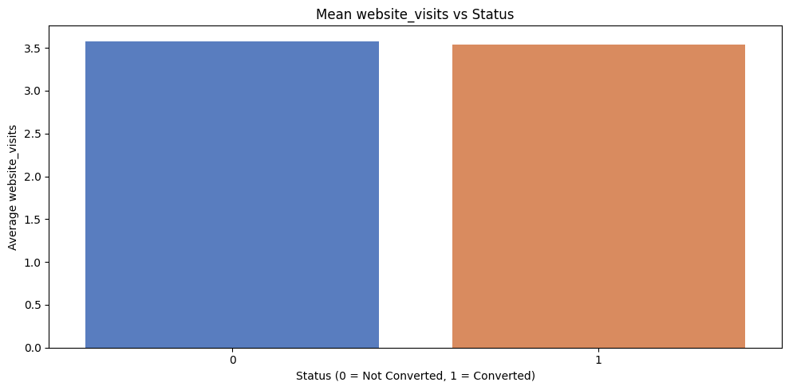

```
--------------------------------------------------

--- Mean of time_spent_on_website by Status ---
status
0    577.42071
1   1068.39797
Name: time_spent_on_website, dtype: float64
```

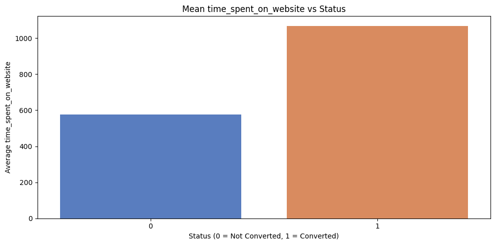

```
--------------------------------------------------

--- Mean of page_views_per_visit by Status ---
status
0   3.02573
1   3.02705
Name: page_views_per_visit, dtype: float64
```

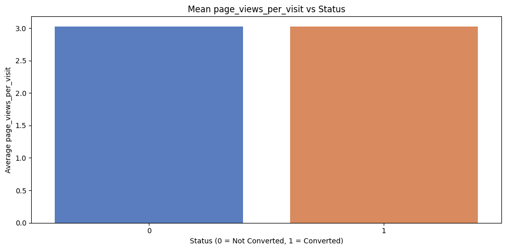

```python
for col in cont_cols:
    if col != 'status':
        # 1. O NÚMERO: Cálculo da média de cada variável por Status
        print(f"\n--- Mean of {col} by Status ---")
        mean_values = df.groupby('status')[col].mean()
        print(mean_values)

        # 2. O GRÁFICO: Barplot da média
        plt.figure(figsize=(10, 5))
        sns.barplot(x='status', y=col, data=df, palette='muted', errorbar=None)

        plt.title(f"Mean {col} vs Status")
        plt.ylabel(f"Average {col}")
        plt.xlabel("Status (0 = Not Converted, 1 = Converted)")

        plt.tight_layout()
        plt.show()
        print("-" * 50)
```

##### **Observations:**

**Age**

Converted leads are slightly older (48.7 years) compared to non-converted (45.2 years).

Older prospects may have stronger motivation for upskilling.

**Website Visits**

Very similar average between converted and non-converted leads.

Number of visits alone is not a strong differentiator.

**Time Spent on Website**

Converted leads spend almost double the time (1068 sec vs 577 sec).

This is one of the strongest behavioral indicators of conversion.

Time spent reflects interest and engagement.

**Page Views per Visit**

Almost identical averages.

This variable alone does not strongly separate converted vs non-converted users.

##### **Direct Answers to the EDA Questions**

1. How does current occupation affect lead status?

Yes, current occupation has a significant impact on conversion.

Professionals have the highest conversion rate (35.5%).

Unemployed leads convert at 26.6%.

Students have the lowest conversion rate (11.7%).

Conclusion: Working professionals are much more likely to convert. This may be because they:

Have higher purchasing power

Are actively seeking career advancement

See direct ROI in upskilling

Students show the lowest likelihood of conversion, possibly due to limited financial capacity.

2. Do the first channels of interaction impact lead status?

Yes, the first interaction channel strongly impacts conversion.

Website leads convert at 45.6%.

Mobile App leads convert at only 10.5%.

Conclusion: Leads who first interact through the website are significantly more likely to convert. This suggests:

Website users may have stronger purchase intent.

Mobile App users may be more exploratory or casual visitors.

This variable appears to be a strong predictor of conversion.

3. Which mode of interaction works best? (Last Activity)

Based on last activity:

Website Activity -> 38.5% conversion

Email Activity -> 30.3%

Phone Activity -> 21.3%

Conclusion: Website-based engagement and email communication perform better than phone calls.

Phone interactions show the lowest conversion rate, suggesting:

Cold calls may be less effective.

Digital engagement may indicate higher intent.

4. Which acquisition channels have the highest conversion rate?

Most marketing channels (print, digital, educational) show only small differences (~30% conversion).

However:

Referral leads convert at 67.7%

Non-referral leads convert at 29.1%

Conclusion: Referrals are by far the most powerful acquisition channel, even though they represent only 2% of total leads.

This suggests:

Trust-based marketing is highly effective.

Referral programs could be expanded.

5. Does profile completion increase the chances of conversion?

Yes — very strongly.

High completion -> 41.8% conversion

Medium -> 18.9%

Low -> 7.5%

Conclusion: There is a clear positive relationship between engagement level (profile completion) and conversion.

The more information a lead provides, the higher the probability of conversion.

This is one of the strongest predictors identified in the EDA.

### Correlation Matrix and Pairplot

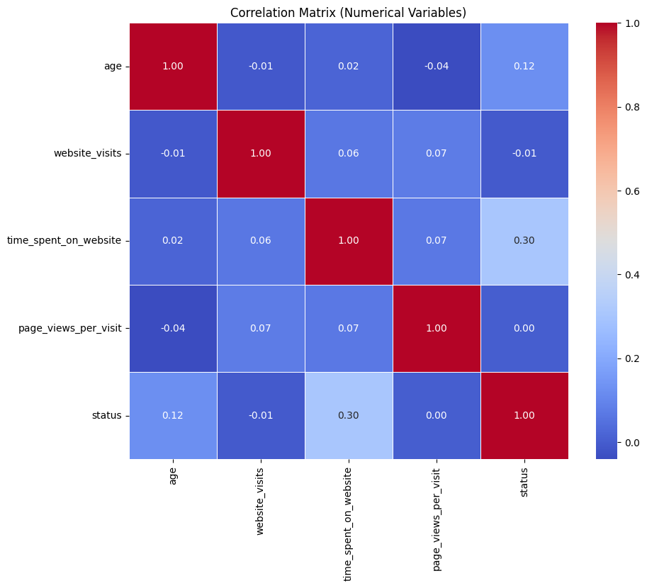

```python
cont_cols = df.select_dtypes(include=['int64','float64']).columns

plt.figure(figsize=(10,8))
sns.heatmap(df[cont_cols].corr(),
            annot=True,
            cmap='coolwarm',
            fmt=".2f",
            linewidths=0.5)

plt.title("Correlation Matrix (Numerical Variables)")
plt.show()
```

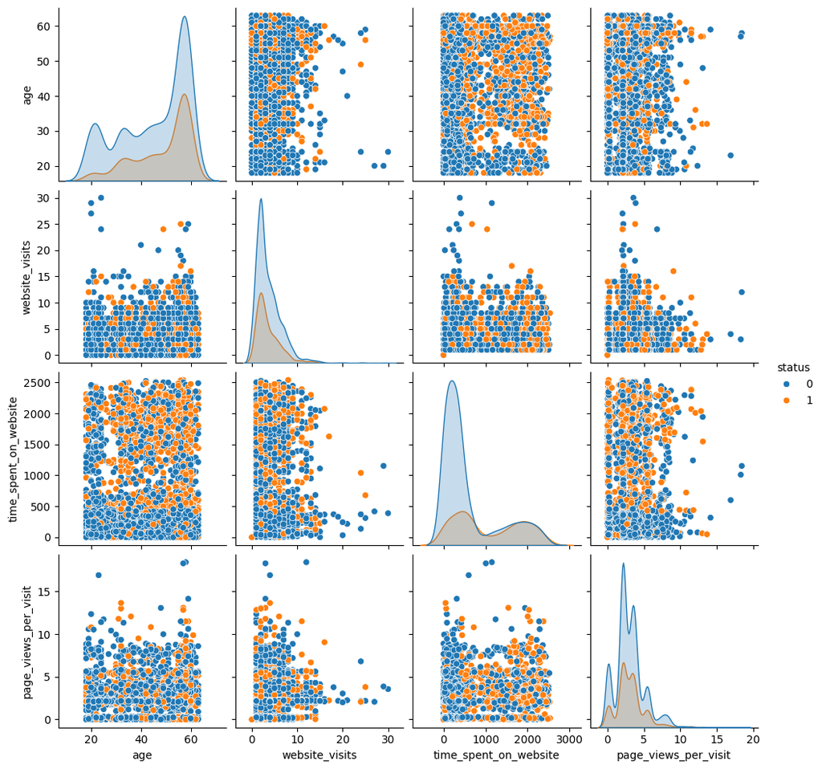

```python
sns.pairplot(df[['age',
                 'website_visits',
                 'time_spent_on_website',
                 'page_views_per_visit',
                 'status']],
             hue='status')
plt.show()
```

##### **Obsarvation:**

A correlation heatmap was used to understand relationships between numerical variables. However, for categorical variables, conversion rate analysis and bar plots were more appropriate to evaluate their relationship with lead status.

In addition, a pairplot visualization was generated for the main numerical variables with the target variable as hue. This allowed a visual inspection of class separation and potential nonlinear patterns that may not be fully captured by correlation coefficients.

The correlation matrix indicates that there is no strong linear relationship among the numerical variables, as most correlation coefficients are close to zero.

The only moderately noticeable relationship is between time_spent_on_website and status (0.30), suggesting that leads who spend more time on the website are more likely to convert. This finding is also visually supported in the pairplot, where converted leads tend to show higher values for time spent compared to non-converted leads.

Age shows a weak positive correlation with status (0.12), indicating that slightly older leads may have a higher probability of converting, although the effect is limited.

Website_visits (-0.01) and page_views_per_visit (0.00) show almost no correlation with the target variable, suggesting that frequency of visits or number of pages viewed alone do not strongly influence conversion. The pairplot further confirms the lack of clear separation between classes for these variables.

Overall, the analysis suggests:

No multicollinearity concerns among numerical predictors.

No strong linear relationships between predictors.

Time_spent_on_website appears to be the most relevant numerical variable for predicting lead conversion.

Visual inspection through the pairplot reinforces that behavioral engagement (time spent) is a stronger signal than simple visit frequency.

## Data Preprocessing

- Missing value treatment (if needed)
- Feature engineering (if needed)
- Outlier detection and treatment (if needed)
- Preparing data for modeling
- Any other preprocessing steps (if needed)

```python
# 1. Drop the ID column
df.drop('ID', axis=1, inplace=True)

# 2. Converting Yes/No flags to 1/0
binary_cols = ['print_media_type1', 'print_media_type2',
               'digital_media', 'educational_channels', 'referral']

for col in binary_cols:
    df[col] = df[col].apply(lambda x: 1 if x == 'Yes' else 0)

# 3. Creating Dummy Variables for categorical variables
df = pd.get_dummies(
    df,
    columns=['profile_completed',
             'current_occupation',
             'first_interaction',
             'last_activity'],
    drop_first=True
)

# Checking the processed dataframe
display(df.head())
```

|  | age | website_visits | time_spent_on_website | page_views_per_visit | print_media_type1 | print_media_type2 | digital_media | educational_channels | referral | status | profile_completed_Low | profile_completed_Medium | current_occupation_Student | current_occupation_Unemployed | first_interaction_Website | last_activity_Phone Activity | last_activity_Website Activity |
| --- | --- | --- | --- | --- | --- | --- | --- | --- | --- | --- | --- | --- | --- | --- | --- | --- | --- |
| 0 | 57 | 7 | 1639 | 1.86100 | 1 | 0 | 1 | 0 | 0 | 1 | False | False | False | True | True | False | True |
| 1 | 56 | 2 | 83 | 0.32000 | 0 | 0 | 0 | 1 | 0 | 0 | False | True | False | False | False | False | True |
| 2 | 52 | 3 | 330 | 0.07400 | 0 | 0 | 1 | 0 | 0 | 0 | False | True | False | False | True | False | True |
| 3 | 53 | 4 | 464 | 2.05700 | 0 | 0 | 0 | 0 | 0 | 1 | False | False | False | True | True | False | True |
| 4 | 23 | 4 | 600 | 16.91400 | 0 | 0 | 0 | 0 | 0 | 0 | False | False | True | False | True | False | False |

##### **Observations:**

**Data Transformation**

In this section, the raw data was transformed into a machine-learning-ready format. Since most machine learning algorithms require numerical inputs, the following preprocessing steps were performed:

**Column Removal**

The ID column was dropped. As a unique identifier for each lead, it does not carry predictive information about the target variable (status). Keeping it could introduce noise and increase the risk of overfitting.

**Binary Transformation**

Several interaction flags (print_media_type1, print_media_type2, digital_media, educational_channels, and referral) were originally stored as "Yes/No" strings. These were converted into binary integers (1 for "Yes", 0 for "No") to make them suitable for numerical computation.

**One-Hot Encoding (Categorical Variables)**

For the categorical variables (profile_completed, current_occupation, first_interaction, and last_activity), One-Hot Encoding was applied.

Although profile_completed has an apparent ranking (Low, Medium, High), we chose not to apply ordinal encoding (0,1,2). Assigning numerical values would implicitly assume equal and linear distance between the categories, which may not reflect the true relationship with the target variable. To avoid imposing an artificial linear structure, it was treated as a categorical variable and encoded using dummy variables instead.

We used drop_first=True to remove one category from each encoded variable. This prevents multicollinearity (the dummy variable trap) and keeps the feature space more compact. While tree-based models are generally robust to correlated features, reducing redundancy improves clarity and computational efficiency.

**Missing Value Treatment**

Before proceeding with modeling, the dataset was examined for missing values.

A complete inspection showed that no significant missing values were present across the variables. Since there were no null entries that could bias the model or reduce statistical reliability, no imputation techniques (such as mean, median, or mode replacement) were required.

As a result, all observations were retained for further analysis and modeling.

## Outlier Visualization

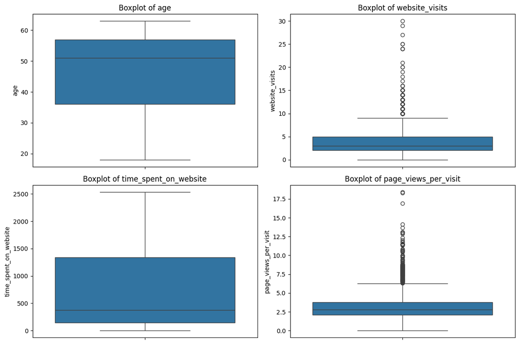

```python
numerical_cols = ['age', 'website_visits',
                  'time_spent_on_website',
                  'page_views_per_visit']

plt.figure(figsize=(12,8))

for i, col in enumerate(numerical_cols, 1):
    plt.subplot(2, 2, i)
    sns.boxplot(y=df[col])
    plt.title(f'Boxplot of {col}')

plt.tight_layout()
plt.show()
```

##### **Observations:**

Boxplots were used to visually inspect the presence of outliers in the numerical variables (age, website_visits, time_spent_on_website, and page_views_per_visit).

The analysis indicates:

website_visits and page_views_per_visit show positive skewness with some upper-end outliers.

time_spent_on_website also presents a right-skewed distribution with a few high-value observations.

The detected outliers are not extremely distant from the main distribution and likely represent highly engaged users rather than data entry errors.

Since Decision Tree and Random Forest models are robust to outliers and do not rely on distance-based calculations, no outlier removal or transformation was performed.

Removing these values could potentially eliminate meaningful behavioral information, particularly from highly interested leads.

## EDA

- It is a good idea to explore the data once again after manipulating it.

```python
print(df.shape)
print(df.dtypes)
```

```
(4612, 17)
age                                 int64
website_visits                      int64
time_spent_on_website               int64
page_views_per_visit              float64
print_media_type1                   int64
print_media_type2                   int64
digital_media                       int64
educational_channels                int64
referral                            int64
status                              int64
profile_completed_Low                bool
profile_completed_Medium             bool
current_occupation_Student           bool
current_occupation_Unemployed        bool
first_interaction_Website            bool
last_activity_Phone Activity         bool
last_activity_Website Activity       bool
dtype: object
```

##### **Observations:**

After preprocessing, the dataset contains 4,612 observations and 17 variables, including the target variable (status).

All features are now in a machine-learning-ready format:

Numerical variables (age, website_visits, time_spent_on_website, page_views_per_visit) are stored as integer or float types.

Binary variables (print_media_type1, print_media_type2, digital_media, educational_channels, referral, and status) are properly encoded as integers (0/1).

Dummy variables created through One-Hot Encoding are represented as boolean values (True/False), which can be interpreted numerically by most machine learning algorithms.

The transformation successfully removed categorical string variables and converted the dataset into a fully numerical structure, making it suitable for model training.

## Multicollinearity (VIF)

```python
from statsmodels.stats.outliers_influence import variance_inflation_factor
X = df.drop('status', axis=1).copy()

# Convert boolean columns to int
bool_cols = X.select_dtypes(include=['bool']).columns
X[bool_cols] = X[bool_cols].astype(int)

vif_data = pd.DataFrame()
vif_data["Feature"] = X.columns
vif_data["VIF"] = [variance_inflation_factor(X.values, i)
                   for i in range(X.shape[1])]

vif_data.sort_values(by="VIF", ascending=False)
```

|  | Feature | VIF |
| --- | --- | --- |
| 0 | age | 6.90336 |
| 3 | page_views_per_visit | 3.24187 |
| 1 | website_visits | 2.55026 |
| 13 | first_interaction_Website | 2.16792 |
| 2 | time_spent_on_website | 1.95689 |
| 10 | profile_completed_Medium | 1.92922 |
| 12 | current_occupation_Unemployed | 1.54106 |
| 14 | last_activity_Phone Activity | 1.51706 |
| 15 | last_activity_Website Activity | 1.45717 |
| 11 | current_occupation_Student | 1.33960 |
| 7 | educational_channels | 1.17856 |
| 6 | digital_media | 1.13066 |
| 4 | print_media_type1 | 1.12165 |
| 5 | print_media_type2 | 1.05511 |
| 9 | profile_completed_Low | 1.05158 |
| 8 | referral | 1.02768 |

##### **Observations:**

The Variance Inflation Factor (VIF) was calculated to assess potential multicollinearity among the predictor variables.

Most features present VIF values close to 1, indicating very low correlation with other independent variables. This suggests that multicollinearity is not a significant concern in the dataset.

The highest VIF observed is for age (6.90). Although this value is moderately elevated, it remains below the commonly used critical threshold of 10, indicating that it does not pose a serious multicollinearity issue. Additionally, since tree-based models are not highly sensitive to multicollinearity, this value does not compromise model performance.

Other numerical variables such as page_views_per_visit (3.24) and website_visits (2.55) show mild correlation but remain within acceptable limits.

Overall, the VIF analysis confirms that:

There are no severe multicollinearity issues.

The feature set is stable for modeling.

No additional feature removal is required at this stage.

## Feature Scaling

Feature scaling was not applied to the dataset.

Tree-based models such as Decision Tree and Random Forest do not rely on distance calculations or gradient optimization. Instead, they split data based on threshold values, making them invariant to feature scaling.

Therefore, normalization or standardization was not required for this project.

## Train-Test Split

```python
# Separating target variable and predictors
Y = df['status']
X = df.drop(columns=['status'])

# Splitting the data (70% train / 30% test) with stratification
X_train, X_test, y_train, y_test = train_test_split(
    X,
    Y,
    test_size=0.3,
    random_state=1,
    stratify=Y
)

# Checking shapes
print("X_train shape:", X_train.shape)
print("X_test shape:", X_test.shape)
print("y_train distribution:\n", y_train.value_counts(normalize=True))
print("y_test distribution:\n", y_test.value_counts(normalize=True))
```

```
X_train shape: (3228, 16)
X_test shape: (1384, 16)
y_train distribution:
 status
0   0.70136
1   0.29864
Name: proportion, dtype: float64
y_test distribution:
 status
0   0.70159
1   0.29841
Name: proportion, dtype: float64
```

##### **Observations:**

The dataset was divided into training and testing sets using a 70:30 split ratio.

70% of the data was used for model training.

30% was reserved for model evaluation.

Stratification was applied based on the target variable (status) to ensure that the proportion of converted (30%) and non-converted (70%) leads remains consistent in both the training and testing sets.

This approach ensures:

Fair model evaluation

Balanced representation of both classes

More reliable performance metrics

The random_state parameter was set to 1 to ensure reproducibility of results.

Overall, the dataset is now properly structured and ready for model building.

## Evaluation Function

```python
# Creating metric function
def metrics_score(actual, predicted):

    print("Classification Report:\n")
    print(classification_report(actual, predicted))

    cm = confusion_matrix(actual, predicted)

    plt.figure(figsize=(8,5))
    sns.heatmap(cm,
                annot=True,
                fmt='d',
                cmap='Blues',
                xticklabels=['Not Converted', 'Converted'],
                yticklabels=['Not Converted', 'Converted'])

    plt.ylabel('Actual')
    plt.xlabel('Predicted')
    plt.title('Confusion Matrix')
    plt.show()
```

**Observations:**

The metrics_score function provides a comprehensive evaluation of the classification model by combining numerical performance metrics with a visual representation through the confusion matrix.

From the classification report, we obtain:

Precision -> How reliable the model is when predicting Status = 1.

Recall -> How well the model correctly identifies actual Status = 1 cases.

F1-score -> The balance between precision and recall.

Support -> The number of observations in each Status class.

## Building a Decision Tree model

```python
df['status'].value_counts(normalize=True)
```

| status | proportion |
| --- | --- |
| 0 | 0.70143 |
| 1 | 0.29857 |

**dtype:** float64

##### **Observations:**

The dataset is imbalanced, with approximately 70% of leads labeled as non-converted (Status 0) and 30% as converted (Status 1). This imbalance can lead the model to favor the majority class, potentially missing a significant number of actual conversions.

```python
# Creating the model (handling class imbalance for Status)
dt = DecisionTreeClassifier(
    class_weight = {0: 0.30, 1: 0.70},
    random_state=1
)

# Fitting the model
dt.fit(X_train, y_train)
```

```
DecisionTreeClassifier(class_weight={0: 0.3, 1: 0.7}, random_state=1)
```

##### **Observations:**

Since the primary objective is to **maximize recall for the converted class (Status 1)**, class weights were adjusted to {0: 0.30, 1: 0.70}. This increases the penalty for misclassifying converted leads, reducing false negatives and improving the model’s ability to identify as many true conversions as possible. Prioritizing recall is essential in this context because failing to identify potential converted leads represents a greater business cost than incorrectly flagging non-converted ones.

```
Decision Tree - Training Performance
Classification Report:

              precision    recall  f1-score   support

           0       1.00      1.00      1.00      2264
           1       1.00      1.00      1.00       964

    accuracy                           1.00      3228
   macro avg       1.00      1.00      1.00      3228
weighted avg       1.00      1.00      1.00      3228
```

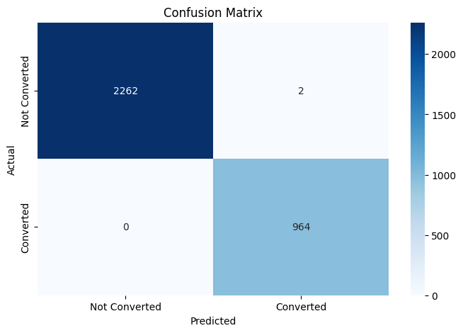

```
Decision Tree - Test Performance
Classification Report:

              precision    recall  f1-score   support

           0       0.85      0.86      0.85       971
           1       0.66      0.63      0.65       413

    accuracy                           0.79      1384
   macro avg       0.75      0.75      0.75      1384
weighted avg       0.79      0.79      0.79      1384
```

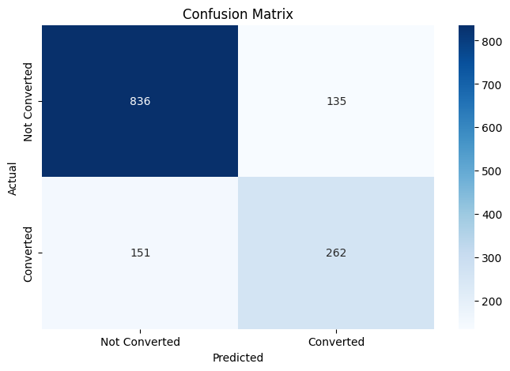

```python
# Predictions
y_train_pred_dt = dt.predict(X_train)
y_test_pred_dt = dt.predict(X_test)

# Evaluating performance
print("Decision Tree - Training Performance")
metrics_score(y_train, y_train_pred_dt)

print("Decision Tree - Test Performance")
metrics_score(y_test, y_test_pred_dt)
```

**Observations:**

The Decision Tree model achieved perfect performance on the training dataset (100% accuracy, precision, recall, and F1-score for both classes). This strongly indicates that the model has memorized the training data, which is a clear sign of overfitting.

However, when evaluated on the test dataset, performance drops considerably:

Overall accuracy decreases to 80%.

For Status = 0, the model performs relatively well (F1-score = 0.85).

For Status = 1, performance is noticeably lower (F1-score = 0.65).

**Recall for Status = 1** is 0.63, meaning the model fails to correctly identify about 37% of actual positive cases.

The gap between training accuracy (100%) and test accuracy (80%) confirms that the model does not generalize well to unseen data.

## Feature importance - Decision Tree

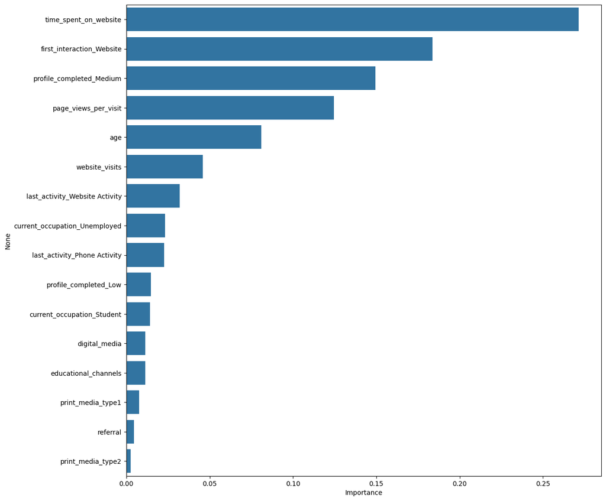

```python
# Plot the feature importance

importances = dt.feature_importances_
columns = X.columns
importance_df = pd.DataFrame(importances, index = columns, columns = ['Importance']).sort_values(by = 'Importance', ascending = False)
plt.figure(figsize = (13, 13))
sns.barplot(data = importance_df, x = importance_df.Importance, y = importance_df.index)
```

```python
feature_importance = pd.DataFrame({
    'Feature': X_train.columns,
    'Importance': dt.feature_importances_
})

feature_importance = feature_importance.sort_values(by='Importance', ascending=False)

print(feature_importance)
```

```
                           Feature  Importance
2            time_spent_on_website     0.27146
13       first_interaction_Website     0.18357
10        profile_completed_Medium     0.14933
3             page_views_per_visit     0.12445
0                              age     0.08084
1                   website_visits     0.04600
15  last_activity_Website Activity     0.03207
12   current_occupation_Unemployed     0.02317
14    last_activity_Phone Activity     0.02269
9            profile_completed_Low     0.01473
11      current_occupation_Student     0.01420
6                    digital_media     0.01139
7             educational_channels     0.01128
4                print_media_type1     0.00756
8                         referral     0.00456
5                print_media_type2     0.00268
```

##### **Observations:**

he feature importance analysis shows that time_spent_on_website is by far the most influential variable in predicting Status, with a significantly higher importance than the remaining features. This indicates that user engagement duration is the strongest driver of the model’s decision.

The second most relevant variable is first_interaction_Website, followed closely by profile_completed_Medium and page_views_per_visit. These variables are also directly related to user engagement and interaction behavior, reinforcing the idea that behavioral patterns are more predictive than static characteristics.

Age and website_visits have moderate importance, contributing to the model but with substantially less influence than engagement metrics.

Other variables such as:

last_activity_Website Activity

current_occupation_Unemployed

last_activity_Phone Activity

media channels (print, digital, referral, educational channels)

profile_completed_Low

current_occupation_Student

have relatively low importance, meaning they contribute only marginally to the model’s decision process.

Key Insight

The model relies predominantly on engagement-based features rather than demographic or acquisition channel variables. This suggests that user behavior on the platform is a much stronger predictor of Status than background characteristics or marketing source.

## Do we need to prune the tree?

Yes, pruning is necessary in this case.

The original Decision Tree achieved perfect performance on the training dataset (100% accuracy), but significantly lower performance on the test dataset (around 80%). This large gap clearly indicates overfitting.

Decision Trees are prone to overfitting when they are allowed to grow without constraints. By default, the model keeps splitting until all leaves are pure or contain very few samples, which leads to memorization of the training data rather than learning generalizable patterns.

Pruning helps by reducing the complexity of the tree and improving its ability to generalize to unseen data.

This can be achieved by tuning hyperparameters such as:

max_depth

min_samples_leaf

min_samples_split

```python
# Choose the type of classifier
d_tree_tuned = DecisionTreeClassifier(random_state = 7, class_weight = {0: 0.3, 1: 0.7})

# Grid of parameters to choose from
parameters = {'max_depth': np.arange(2, 10),
              'criterion': ['gini', 'entropy'],
              'min_samples_leaf': [5, 10, 20, 25]
             }

# Type of scoring used to compare parameter combinations - recall score for class 1
scorer = metrics.make_scorer(recall_score, pos_label = 1)

# Run the grid search
grid_obj = GridSearchCV(d_tree_tuned, parameters, scoring = scorer, cv = 5)

grid_obj = grid_obj.fit(X_train, y_train)

# Set the classifier to the best combination of parameters
d_tree_tuned = grid_obj.best_estimator_

# Fit the best algorithm to the data
d_tree_tuned.fit(X_train, y_train)
```

```
DecisionTreeClassifier(class_weight={0: 0.3, 1: 0.7}, criterion='entropy',
                       max_depth=np.int64(3), min_samples_leaf=5,
                       random_state=7)
```

```python
print(grid_obj.best_estimator_)
```

```
DecisionTreeClassifier(class_weight={0: 0.3, 1: 0.7}, criterion='entropy',
                       max_depth=np.int64(3), min_samples_leaf=5,
                       random_state=7)
```

##### **Observations:**

Justification for Hyperparameter Selection

The goal of tuning the Decision Tree was to move away from the overfitted baseline model and create a classifier that generalizes well while prioritizing the identification of potential customers (Class 1).

class_weight = {0: 0.3, 1: 0.7}: This was the most critical choice. Since we have a class imbalance (70/30), we assigned a higher weight to the minority class (Status 1). This forces the model to focus on correctly predicting conversions, even if it leads to some false positives.

max_depth: np.arange(2, 10): By limiting the depth to a maximum of 9, we prevent the tree from growing too deep and "memorizing" the training data. This range explores both simple models (low variance) and more complex ones (higher detail).

min_samples_leaf: [5, 10, 20, 25]: This parameter ensures that each terminal node has a minimum number of samples. Higher values (20, 25) act as a strong regularizer, smoothing the model and preventing it from creating rules based on outliers.

scoring = scorer (Recall): Since missing a potential lead (False Negative) is more costly for ExtraaLearn than contacting a non-converter (False Positive), we optimized the grid search specifically for Recall of Class 1.

The GridSearch selected a max_depth of 3. This indicates that a very simple set of rules is enough to capture the most important patterns in lead conversion. A shallower tree is highly desirable in business because it is completely transparent and easy to explain to non-technical stakeholders.

Entropy vs. Gini: The choice of Entropy suggests that for this specific dataset, the mathematical calculation of "Information Gain" was more effective at creating pure nodes than the Gini impurity, especially when dealing with the 0.3/0.7 class weights.

```
Decision Tree - Training Performance
Classification Report:

              precision    recall  f1-score   support

           0       0.95      0.75      0.84      2264
           1       0.60      0.91      0.72       964

    accuracy                           0.79      3228
   macro avg       0.78      0.83      0.78      3228
weighted avg       0.85      0.79      0.80      3228
```

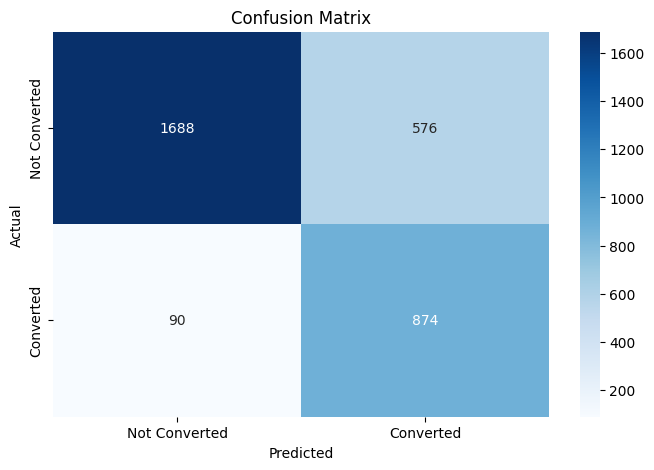

```
Decision Tree - Test Performance
Classification Report:
```

```
              precision    recall  f1-score   support

           0       0.94      0.73      0.82       971
           1       0.58      0.89      0.70       413

    accuracy                           0.78      1384
   macro avg       0.76      0.81      0.76      1384
weighted avg       0.83      0.78      0.79      1384
```

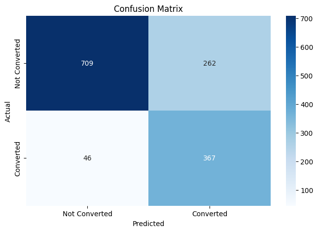

```python
y_train_pred_dt = d_tree_tuned.predict(X_train)

y_test_pred_dt = d_tree_tuned.predict(X_test)

print("Decision Tree - Training Performance")
metrics_score(y_train, y_train_pred_dt)

print("Decision Tree - Test Performance")
metrics_score(y_test, y_test_pred_dt)
```

##### **Observations:**

Improvement in Recall:

After pruning, the model achieved a **Recall of 0.89 for the converted class (Status 1)** on the test set, compared to 0.63 previously. This indicates a substantial improvement in the model’s ability to identify potential converted leads, aligning with the objective of maximizing recall for class 1.

Reduced Overfitting and Better Generalization:

The Recall for class 1 is 0.91 on the training set and 0.89 on the test set, showing very consistent performance across datasets. This small gap suggests that the model is no longer overfitting significantly and is generalizing well to unseen data. The pruning process successfully reduced model complexity while maintaining strong predictive power.

Business Trade-off:

There is a decrease in Precision for class 1 (0.58 on the test set), meaning the model generates more false positives. However, this trade-off is acceptable in this context because missing a potential converted lead (false negative) represents a higher business cost than contacting a lead who ultimately does not convert.

## Visualizing the tree

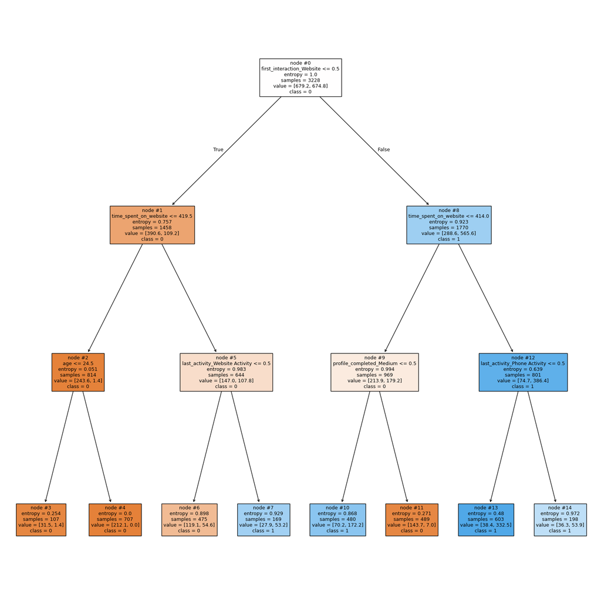

```python
features = list(X.columns)

plt.figure(figsize=(20, 20))

tree.plot_tree(
    d_tree_tuned,
    feature_names=features,
    filled=True,
    fontsize=9,
    node_ids=True,
    class_names=["0", "1"]
)

plt.show()
```

##### **Observations:**

The pruned decision tree shows that first_interaction_Website is the root node, meaning it provides the highest impurity reduction in the model and therefore has the strongest initial splitting power for predicting lead conversion. This suggests that the channel of first interaction plays a critical role in influencing conversion outcomes.

Overall, the visualization confirms that engagement-related variables (time spent, last activity, profile completion) strongly influence conversion likelihood. The pruning process keeps the tree interpretable while preserving strong separation patterns between converted and non-converted leads.

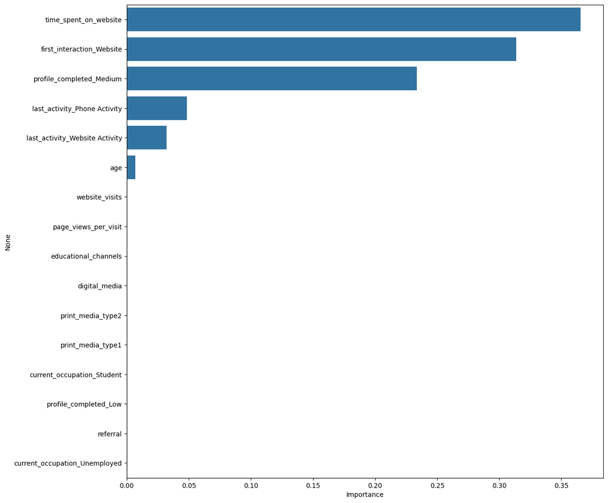

```python
importances = d_tree_tuned.feature_importances_
columns = X.columns
importance_df = pd.DataFrame(importances, index = columns, columns = ['Importance']).sort_values(by = 'Importance', ascending = False)
plt.figure(figsize = (13, 13))
sns.barplot(data = importance_df, x = importance_df.Importance, y = importance_df.index)
```

```python
feature_importance = pd.DataFrame({
    'Feature': X_train.columns,
    'Importance': d_tree_tuned.feature_importances_
})

feature_importance = feature_importance.sort_values(by='Importance', ascending=False)

print(feature_importance)
```

```
                           Feature  Importance
2            time_spent_on_website     0.36555
13       first_interaction_Website     0.31348
10        profile_completed_Medium     0.23370
14    last_activity_Phone Activity     0.04840
15  last_activity_Website Activity     0.03201
0                              age     0.00685
1                   website_visits     0.00000
3             page_views_per_visit     0.00000
7             educational_channels     0.00000
6                    digital_media     0.00000
5                print_media_type2     0.00000
4                print_media_type1     0.00000
11      current_occupation_Student     0.00000
9            profile_completed_Low     0.00000
8                         referral     0.00000
12   current_occupation_Unemployed     0.00000
```

##### **Observations:**

The feature importance results indicate that time_spent_on_website is the most influential variable in the pruned decision tree, contributing approximately 36.6% of the total impurity reduction. This suggests that user engagement, measured by time spent on the website, is the strongest predictor of lead conversion in the model.

Although first_interaction_Website appears as the root node of the tree, it ranks second in overall importance (31.3%). This indicates that while it provides the strongest initial split in the model, time_spent_on_website contributes more consistently across multiple splits throughout the tree, resulting in a higher cumulative importance.

Overall, the feature importance analysis confirms that behavioral and engagement-driven variables dominate the prediction of lead conversion, while demographic and acquisition-source variables contribute minimally in the final pruned structure.

## Building a Random Forest model

```python
rf_estimator = RandomForestClassifier(
    class_weight={0: 0.3, 1: 0.7},
    random_state=1
)

rf_estimator.fit(X_train, y_train)
```

```
RandomForestClassifier(class_weight={0: 0.3, 1: 0.7}, random_state=1)
```

##### **Observations:**

Handling Class Imbalance: Since the original data distribution is approximately 70/30 (Status 0 vs Status 1), we applied a class_weight of {0: 0.3, 1: 0.7}.

Strategy: This specific weighting tells the algorithm to treat the minority class (conversions) as significantly more important. By "penalizing" the model more for missing a conversion than for misclassifying a non-converter, we align the model with ExtraaLearn's business objective: prioritizing lead identification.

## Test Performance - Random Forest

```
Random Forest - Training Performance
Classification Report:

              precision    recall  f1-score   support

           0       1.00      1.00      1.00      2264
           1       1.00      1.00      1.00       964

    accuracy                           1.00      3228
   macro avg       1.00      1.00      1.00      3228
weighted avg       1.00      1.00      1.00      3228
```

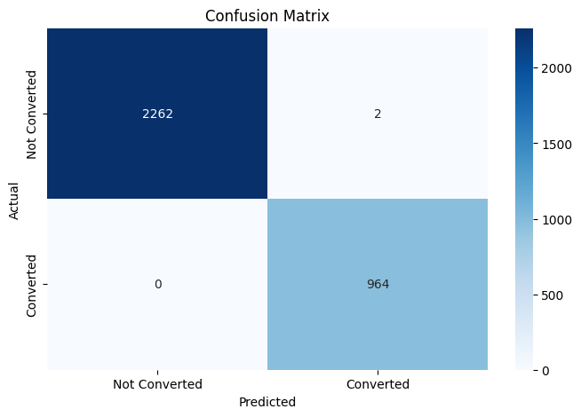

```
Random Forest - Test Performance
```

```
Classification Report:

              precision    recall  f1-score   support

           0       0.88      0.92      0.90       971
           1       0.79      0.72      0.75       413

    accuracy                           0.86      1384
   macro avg       0.84      0.82      0.83      1384
weighted avg       0.86      0.86      0.86      1384
```

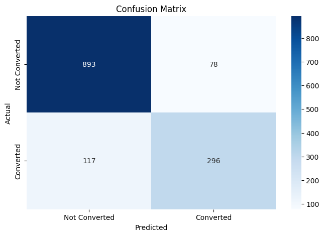

```python
print("Random Forest - Training Performance")
metrics_score(y_train, rf_estimator.predict(X_train))

print("Random Forest - Test Performance")
metrics_score(y_test, rf_estimator.predict(X_test))
```

##### **Observations:**

The Random Forest achieved perfect performance on the training set, with all metrics equal to 1.00 for both classes. While this may seem ideal, such results can indicate potential overfitting, since the model may have learned the training data patterns too specifically and might not generalize equally well to unseen data.

## Feature Importance - Random Forest

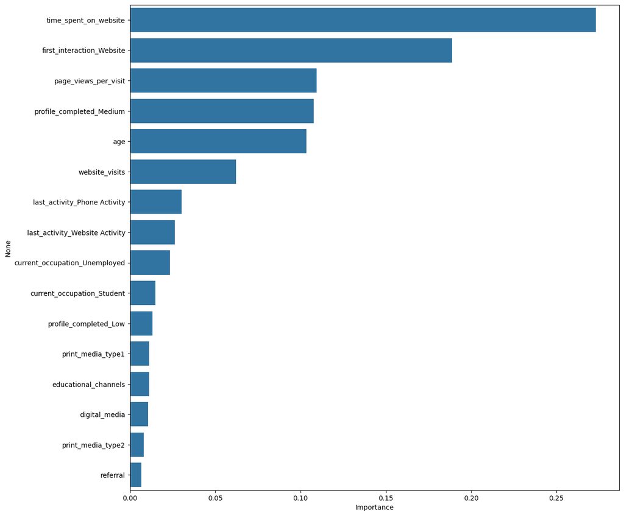

```python
# Plot the feature importance

importances = rf_estimator.feature_importances_
columns = X.columns
importance_df = pd.DataFrame(importances, index = columns, columns = ['Importance']).sort_values(by = 'Importance', ascending = False)
plt.figure(figsize = (13, 13))
sns.barplot(data = importance_df, x = importance_df.Importance, y = importance_df.index)
```

```python
columns = X_train.columns

importance_df = pd.DataFrame({'Feature': columns, 'Importance': importances})

importance_df = importance_df.sort_values(by='Importance', ascending=False)

print(importance_df)
```

```
                           Feature  Importance
2            time_spent_on_website     0.27321
13       first_interaction_Website     0.18873
3             page_views_per_visit     0.10937
10        profile_completed_Medium     0.10773
0                              age     0.10329
1                   website_visits     0.06206
14    last_activity_Phone Activity     0.03021
15  last_activity_Website Activity     0.02634
12   current_occupation_Unemployed     0.02350
11      current_occupation_Student     0.01499
9            profile_completed_Low     0.01309
4                print_media_type1     0.01121
7             educational_channels     0.01107
6                    digital_media     0.01073
5                print_media_type2     0.00790
8                         referral     0.00656
```

##### **Observations:**

Balanced Predictive Power: Unlike the single Decision Tree, the Random Forest shows a more distributed importance across features. This indicates a more robust model that considers multiple signals before making a prediction.

Top Conversion Drivers: Time spent on website (27.3%) and First interaction via Website (18.8%) remain the most critical predictors. This reinforces that digital engagement and the initial touchpoint are the strongest indicators of lead intent.

The Role of Demographics and Browsing Behavior: Interestingly, features like Page views per visit (10.9%), Profile completion - Medium (10.7%), and Age (10.3%) now show significant importance (all above 10%). This suggests that the lead's profile and their specific browsing patterns provide essential context that the simpler model might have overlooked.

Lower-Impact Features: Features like website_visits and last_activity contribute moderately, while marketing flags (media types and referrals) remain at the bottom of the list. This suggests that while acquisition channels bring leads in, their behavioral data after joining the platform is what truly determines conversion.

## Do we need to prune the tree?

Yes. Even though a Random Forest is naturally more robust than a single Decision Tree, The model achieved 100% across all metrics on the training set. This is the definition of "memorization" (overfitting). By "pruning" the forest, which we do by tuning hyperparameters like max_depth and min_samples_leaf forcing the model to focus on the strongest patterns that actually generalize to new leads, rather than noise in the training data.

```python
# Choose the type of classifier
rf_estimator_tuned = RandomForestClassifier(criterion = "entropy", random_state = 7)

# Grid of parameters to choose from
parameters = {
    "n_estimators": [100, 150],
    "max_depth": [3, 5, 7],
    "min_samples_leaf": [20, 30],
    "max_features": ["sqrt", 0.8],
    "class_weight": ["balanced", {0: 0.3, 1: 0.7}]
}

# Type of scoring used to compare parameter combinations - recall score for class 1
scorer = metrics.make_scorer(recall_score, pos_label = 1)

# Run the grid search on the training data using scorer=scorer and cv=5
grid_obj = GridSearchCV(rf_estimator_tuned, parameters, scoring = scorer, cv = 5)

# Fit the grid search to the training data
grid_obj = grid_obj.fit(X_train, y_train)

# Save the best estimator to variable rf_estimator_tuned
rf_estimator_tuned = grid_obj.best_estimator_
```

```python
print(rf_estimator_tuned)
```

```
RandomForestClassifier(class_weight='balanced', criterion='entropy',
                       max_depth=3, max_features=0.8, min_samples_leaf=20,
                       random_state=7)
```

##### **Observations:**

Justification for Hyperparameter Selection (Random Forest)

n_estimators [100, 150]: We chose a solid range of trees to stabilize the predictions. Increasing the number of estimators helps reduce the model's variance, ensuring that the final lead classification is the result of a robust consensus across the forest.

max_depth [3, 5, 7]: Following the insight from the Tuned Decision Tree—where a depth of 3 was found to be optimal—we included lower depth values. This forces the forest to focus on high-level, statistically significant features rather than over-complicating the decision boundaries.

min_samples_leaf [20, 30]: Based on the Decision Tree results where a min_samples_leaf of 5 was effective for a single tree, we tested higher values (20, 30) for the Random Forest. This serves as a stronger regularizer for an ensemble, ensuring that the aggregated nodes across 100+ trees are based on large, stable clusters of data rather than noise. (As demonstrated in the "Technical Appendix" at the end of this notebook, a separate test was conducted comparing values 5 and 20, and the results remained identical.)

max_features ["sqrt", 0.8]: We compared the standard square root (approx. 4 features) against a more aggressive 80% feature set. This allows the GridSearchCV to decide if the forest performs better by forcing diversity between trees or by allowing each tree to have a nearly complete view of the key drivers (like Time Spent on Website).

class_weight ["balanced", {0: 0.3, 1: 0.7}]: Given the 70/30 class imbalance, we tested the 'balanced' mode against a custom weight. This is critical for driving the Recall higher, as it specifically penalizes the model more for missing a potential converter (Status 1).

```
Random Forest - Training Performance
Classification Report:

              precision    recall  f1-score   support

           0       0.95      0.75      0.84      2264
           1       0.60      0.91      0.72       964

    accuracy                           0.79      3228
   macro avg       0.78      0.83      0.78      3228
weighted avg       0.85      0.79      0.80      3228
```

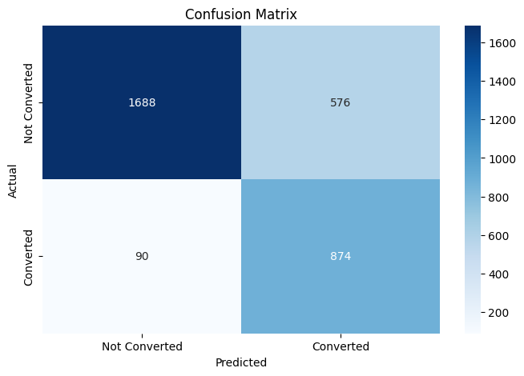

```
Random Forest - Test Performance
```

```
Classification Report:

              precision    recall  f1-score   support

           0       0.94      0.73      0.82       971
           1       0.58      0.89      0.71       413

    accuracy                           0.78      1384
   macro avg       0.76      0.81      0.76      1384
weighted avg       0.83      0.78      0.79      1384
```

```python
print("Random Forest - Training Performance")
metrics_score(y_train, rf_estimator_tuned.predict(X_train))

print("Random Forest - Test Performance")
metrics_score(y_test, rf_estimator_tuned.predict(X_test))
```

[output not shown]

##### **Observations:**

Convergent Performance (Recall Focus): Both models have now converged to a very similar performance profile after tuning. Both prioritized Recall (0.89), successfully identifying 89% of potential converters. This indicates that the tuning process successfully pushed both models to their maximum potential for capturing leads.

Precision and F1-Score Stability: The Tuned Random Forest shows a slightly better F1-Score (0.71 vs 0.70) on the test set compared to the Decision Tree. While the Precision is identical (0.58), the Random Forest's ensemble nature provides a marginal edge in the balance between capturing leads and maintaining overall model health.

Exceptional Generalization: Both models demonstrate nearly perfect generalization. The drop in accuracy from Training (0.79) to Test (0.78) is negligible. This confirms that the constraints applied, specifically the max_depth of 3 and min_samples_leaf, successfully eliminated the overfitting seen in the baseline models.

The Power of Simplicity: It is noteworthy that both the single tree and the forest achieved their best results with a max_depth of 3. This proves that the conversion logic for ExtraaLearn leads is driven by a few highly influential features rather than a complex web of variables."

## Feature Importance - Random Forest Tuned

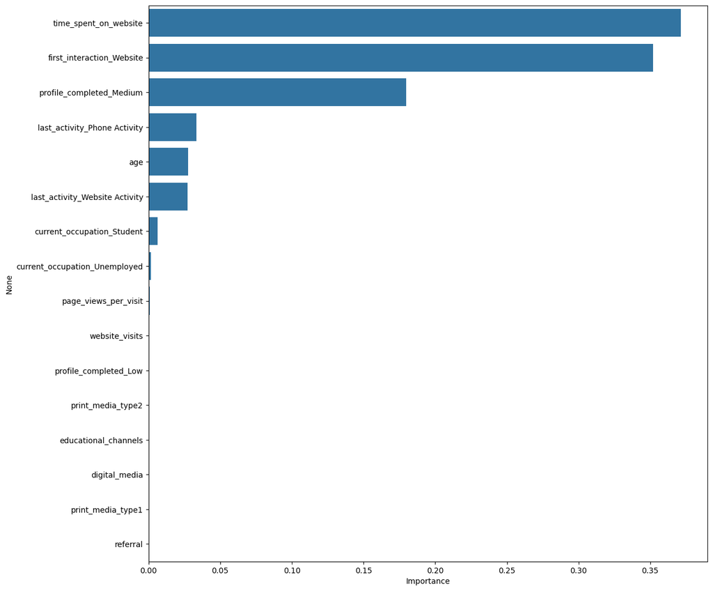

```python
importances = rf_estimator_tuned.feature_importances_
columns = X.columns
importance_df = pd.DataFrame(importances, index = columns, columns = ['Importance']).sort_values(by = 'Importance', ascending = False)
plt.figure(figsize = (13, 13))
sns.barplot(data = importance_df, x = importance_df.Importance, y = importance_df.index)
```

```python
columns = X_train.columns

importance_df = pd.DataFrame({'Feature': columns, 'Importance': importances})

importance_df = importance_df.sort_values(by='Importance', ascending=False)

print(importance_df)
```

```
                           Feature  Importance
2            time_spent_on_website     0.37149
13       first_interaction_Website     0.35207
10        profile_completed_Medium     0.17982
14    last_activity_Phone Activity     0.03330
0                              age     0.02754
15  last_activity_Website Activity     0.02703
11      current_occupation_Student     0.00610
12   current_occupation_Unemployed     0.00155
3             page_views_per_visit     0.00083
1                   website_visits     0.00020
9            profile_completed_Low     0.00007
5                print_media_type2     0.00000
7             educational_channels     0.00000
6                    digital_media     0.00000
4                print_media_type1     0.00000
8                         referral     0.00000
```

##### **Observations:**

The feature importance analysis reveals a highly concentrated decision-making process, where a few key drivers dictate the vast majority of the model's predictive power.

The "Golden Duo" of Engagement: time_spent_on_website (37.1%) and first_interaction_Website (35.2%) are, by far, the most influential predictors. Together, they account for over 72% of the model's logic. This confirms that leads who spend significant time on the site and choose the website as their initial touchpoint are the most likely to convert.

Marginal Impact of Demographic/Passive Data: Interestingly, variables like age (2.7%), current_occupation, and page_views_per_visit have very low importance. This suggests that what the lead does (behavioral data) is significantly more predictive than who the lead is (demographic data).

Redundant Channels: Several features, such as digital_media, educational_channels, and referral, show 0% importance. This indicates that these channels do not contribute to the final conversion decision in the presence of more dominant features, allowing for potential simplification of future data collection.

## Actionable Insights and Recommendations

Actionable Insights and Recommendations Following the Exploratory Data Analysis (EDA), class imbalance handling, and the fine-tuning of Machine Learning models, we have identified the critical drivers that transform a lead into a customer.

**1 Key Business Insights** The Power of the First Impression: Leads whose first interaction occurs via the Website have a significantly higher probability of conversion. The website is not just a storefront; it is the primary filter for lead quality.

Time is Gold: Time spent on the website emerged as the most important variable. There is a definitive "tipping point" where digital engagement translates into real purchase intent.

The Recall Priority: By prioritizing a Recall of 0.89, ExtraaLearn ensures that nearly 9 out of every 10 potential students are identified. This minimizes the opportunity cost of losing a customer to the competition.

**2 Strategic Recommendations** Optimize Digital Marketing Spend Action: Reallocate the paid media budget toward channels that drive users directly to the Official Website, rather than external forms or third-party landing pages.

Goal: Maximize the volume of leads starting their journey through the highest-converting channel.

Implement a High-Engagement "Fast Track" Action: Set up real-time CRM alerts for the sales team whenever a lead exceeds the average engagement time threshold identified by the model.

Goal: Approach the lead while their interest is at its peak ("strike while the iron is hot").

Gamify Profile Completion Action: Introduce progress bars or small incentives (e.g., free e-books or trial access) for leads with "Low" profiles to complete their data.

Goal: Move leads from "Low" to "Medium/High" categories, increasing the pool of qualified leads for the model.

Sales Resource Allocation Action: Use the Random Forest probability scores to distribute leads. High-probability leads should be assigned to senior consultants, while lower-probability leads can be nurtured via automated email campaigns.

**3 Final Recommendation** The Tuned Random Forest is recommended as the final production model. While it provides the same high Recall (0.89) as the Tuned Decision Tree, its ensemble architecture offers greater long-term stability and robustness. This model ensures that ExtraaLearn maximizes its revenue by capturing the vast majority of potential leads while maintaining a consistent and reliable scoring mechanism for the sales team.

### Technical Appendix

The following test was conducted to evaluate the sensitivity and robustness of the Random Forest model regarding its leaf granularity. By keeping the optimal max_depth of 3 and class_weight as 'balanced', we compared the model’s performance using min_samples_leaf values of 5 (the optimal value for the single Decision Tree) and 20 (the initial choice for the Forest ensemble). The goal was to determine if a more granular leaf structure would yield any gains in Recall or Precision, or if the model’s performance had already reached a state of stability where such micro-adjustments no longer impact the final classification of leads.

```python
Aux1_estimator_tuned = RandomForestClassifier(criterion = "entropy", random_state = 7)

parameters = {
    "n_estimators": [100, 150],
    "max_depth": [3, 5, 7],
    "min_samples_leaf": [20, 30],
    "max_features": ["sqrt", 0.8],
    "class_weight": ["balanced", {0: 0.3, 1: 0.7}]
}


scorer = metrics.make_scorer(recall_score, pos_label = 1)

grid_obj = GridSearchCV(Aux1_estimator_tuned, parameters, scoring = scorer, cv = 5)

grid_obj = grid_obj.fit(X_train, y_train)

Aux1_estimator_tuned = grid_obj.best_estimator_
```

```python
print(Aux1_estimator_tuned)

print("\n \n Random Forest - Test Performance")
metrics_score(y_test, Aux1_estimator_tuned.predict(X_test))
```

```
RandomForestClassifier(class_weight='balanced', criterion='entropy',
                       max_depth=3, max_features=0.8, min_samples_leaf=20,
                       random_state=7)


 Random Forest - Test Performance
Classification Report:

              precision    recall  f1-score   support

           0       0.94      0.73      0.82       971
           1       0.58      0.89      0.71       413

    accuracy                           0.78      1384
   macro avg       0.76      0.81      0.76      1384
weighted avg       0.83      0.78      0.79      1384
```

```python
Aux2_estimator_tuned = RandomForestClassifier(criterion = "entropy", random_state = 7)

parameters = {
    "n_estimators": [100, 150],
    "max_depth": [3, 5, 7],
    "min_samples_leaf": [5, 20, 30],      #ADD 5
    "max_features": ["sqrt", 0.8],
    "class_weight": ["balanced", {0: 0.3, 1: 0.7}]
}


scorer = metrics.make_scorer(recall_score, pos_label = 1)

grid_obj = GridSearchCV(Aux2_estimator_tuned, parameters, scoring = scorer, cv = 5)

grid_obj = grid_obj.fit(X_train, y_train)

Aux2_estimator_tuned = grid_obj.best_estimator_
```

```python
print(Aux2_estimator_tuned)

print("\n \n Random Forest - Test Performance")
metrics_score(y_test, Aux2_estimator_tuned.predict(X_test))
```

```
RandomForestClassifier(class_weight='balanced', criterion='entropy',
                       max_depth=3, max_features=0.8, min_samples_leaf=5,
                       random_state=7)


 Random Forest - Test Performance
Classification Report:

              precision    recall  f1-score   support

           0       0.94      0.73      0.82       971
           1       0.58      0.89      0.71       413

    accuracy                           0.78      1384
   macro avg       0.76      0.81      0.76      1384
weighted avg       0.83      0.78      0.79      1384
```

##### **Observations:**

After performing a separate sensitivity test, it was observed that the model's performance metrics remained exactly the same when comparing min_samples_leaf values of 5 and 20. This result confirms that the primary patterns in the ExtraaLearn dataset are captured by the broader tree structure (defined by the max_depth of 3) rather than the granularity of individual leaf nodes. The fact that the Precision (0.58) and Recall (0.89) did not fluctuate proves that the model has reached a peak state of stability, where it is no longer sensitive to minor parameter adjustments. This provides high confidence that the chosen configuration is robust and will perform consistently when applied to new, unseen leads.

```python
!jupyter nbconvert --execute --to html "/content/Learner_Notebook_Full_Code_Version_Potential_Customers_Prediction (3).ipynb"
```

[output not shown]

[output cut: 136 more lines]

[output not shown]